# Sosyal Medya Analizi

# 1 Youtube Video İstatistikleri

İlk olarak youtube için bir API anahtarı temin edilmelidir. Bunun için [Google API Console](https://console.developers.google.com/apis) adresinden bir adet Youtube Data API anahtarı alınabilir. API anahtarı alındıktan sonra `vosonSML` kütüphanesinden `Authenticate()` işlevi ile doğrulaması gerçekleştirilebilir.

```r
myAPIKey <- "xxxxx"
youtubeAuth <- Authenticate("youtube", apiKey = myAPIKey)
```

# 2 Youtube Verisinin Çekilmesi

YouTube yorum verilerini toplamak için YouTube video kimlikleri (YouTube URL’sinde “=” harfinden sonraki kısım) gereklidir. Bu kimlikler manuel olarak çıkarılabilir veya aşağıdaki komutla URL’lerden otomatik olarak çıkarılabilir:

```r
videoIDs <- GetYoutubeVideoIDs(c("https://www.youtube.com/watch?v=xs9XUjHvZsM", "https://youtu.be/gkvdYmkczPY"))
```

```
Extracted 2 video ids.
```

YouTube video kimliklerini içeren karakter vektörü daha sonra `Collect()` işlevine bir parametre olarak iletilir (aşağıdaki kod ayrıca `Collect()` ’e nakledilen YouTube erişim belirtecini gösterir). Aşağıdaki örnekte, “Çöpçüler Kralı” başlıklı bir YouTube videosundan yorumlar topluyoruz. 5442 adet yorum mevcut. Yorum verileri 12 Kasım 2020’de toplandı: o zamana ait toplam yorum sayısı 5000’in üzerindeydi, ancak toplamak için `maxComments` parametresini kullanıyoruz en fazla 500 üst düzey yorum (ve bu üst düzey yorumlara yapılan tüm yanıt yorumları).

```r
videoIDs <- GetYoutubeVideoIDs("https://www.youtube.com/watch?v=xs9XUjHvZsM")
```

```
Extracted 1 video ids.
```

```r
youtubeData <- youtubeAuth %>% Collect(videoIDs = videoIDs, maxComments = 500, writeToFile = TRUE)
```

```
Video 1 of 1
---------------------------------------------------------------
** video Id: xs9XUjHvZsM
-- API returned more than max comments. Results truncated to first 500 threads.
** Collected threads: 500
** Collecting replies for 37 threads with replies. Please be patient.
.....................................
** Collected replies: 79
** Total video comments: 579
---------------------------------------------------------------
** Total comments collected for all videos 579.
(Estimated API unit cost: 92)
RDS file written: C:/Users/mozturkmen/Desktop/r_ile_veri_analitigi/ders_on_hazirlik/on_hazirlik/2020-11-12_175649-YoutubeData.rds
Done.
```

`Collect()` işlevi şu bağımsız değişkenleri alır (YouTube verilerini toplamak için kullanıldığında): kimlik bilgisi (`Authenticate()` ’den oluşturulan nesne “youtube” sınıf adıyla (yukarıda bunu boru yoluyla iletiyoruz), videoID’ler (bir veya daha fazlasını belirten karakter vektörü) youtube video kimlikleri), maxComments (her videodan kaç tane üst düzey yorumun toplanacağını belirten sayısal tam sayı; varsayılan 1e + 13’tür), writeToFile (döndürülen veri çerçevesinin diske bir `.rds` dosyası olarak yazılıp yazılmayacağı; varsayılan `FALSE`’dir), ve ayrıntılı (veri toplama hakkında bilgi verilip verilmeyeceği; varsayılan `FALSE`’tır).

`Collect()`, aşağıdaki yapıya sahip standart bir R veri çerçevesi (tibble değil) döndürür (veriler anonimliğin korunması için değiştirilmiştir):

```r
glimpse(youtubeData)
```

```
Rows: 579
Columns: 12
$ Comment               <chr> "Hala izleyen yigit evlatlarina selam olsun!"...
$ AuthorDisplayName     <chr> "Meriç Yavuz", "Ahmet Dimli", "Cem Sahin", "D...
$ AuthorProfileImageUrl <chr> "https://yt3.ggpht.com/a/AATXAJwySuMYVcAzJXdW...
$ AuthorChannelUrl      <chr> "http://www.youtube.com/channel/UC_Qt-9cbzYaR...
$ AuthorChannelID       <chr> "UC_Qt-9cbzYaRqNjHm-q2O8A", "UCvkhiFDz5KTA8fF...
$ ReplyCount            <chr> "0", "0", "0", "0", "0", "0", "0", "0", "0", ...
$ LikeCount             <chr> "0", "0", "0", "0", "0", "0", "0", "0", "0", ...
$ PublishedAt           <chr> "2020-11-12T04:39:04Z", "2020-11-11T19:08:25Z...
$ UpdatedAt             <chr> "2020-11-12T04:39:04Z", "2020-11-11T19:08:25Z...
$ CommentID             <chr> "UgzzFmpGTcBkLRnfM394AaABAg", "Ugzahqu0YIetzv...
$ ParentID              <chr> NA, NA, NA, NA, NA, NA, NA, NA, NA, NA, NA, N...
$ VideoID               <chr> "xs9XUjHvZsM", "xs9XUjHvZsM", "xs9XUjHvZsM", ...
```

# 3 Kaydedilen Verinin Çağırılması

Daha önce youtube’dan çekilmiş veriyi tekrar okumak istersek `readRDS` işlevini kullanabiliriz:

```r
# youtubeData <- readRDS('2020-11-12_172227-YoutubeData.rds')
```

# 4 Youtube Ağları

Şu anda YouTube verilerini kullanarak iki tür ağ oluşturmak mümkündür: (1) aktör ağı ve (2) etkinlik ağı.

## 4.1 Aktör Ağı

YouTube aktör ağında düğümler, videolara yorum yapan kullanıcılardır (ve videoların kendileri ağa özel düğümler olarak dahil edilmiştir) ve kenarlar, yorumlarda kullanıcılar arasındaki etkileşimlerdir. Bir videoya yönlendirilen bir yorum olan üst düzey bir yorumu, üst düzey bir yoruma yönelik bir yorum olan yanıt yorumundan ayırt edebiliriz. YouTube kullanıcı arayüzü, bir kullanıcının bir yanıtı başka bir yanıta yönlendirmesine izin vermez. Bununla birlikte, kullanıcılar, yorumlarına yanıt verdikleri kişinin kullanıcı adıyla başlayarak (ve genellikle kullanıcı adının başına “@” ekleyerek) “yanıtı yanıtla” işlevini elde edebilir. Dolayısıyla, j tarafından yazılan en üst düzey bir yoruma yanıt verirsem veya yorumunun başına j’nin kullanıcı adını eklersem, i kullanıcısından j kullanıcısına bir avantaj olacaktır.

```r
actorNetwork <- youtubeData %>% Create("actor") %>% AddText(youtubeData)
```

```
Generating youtube actor network...Done.
Adding text to network...Done.
```

```r
actorGraph <- actorNetwork %>% Graph(writeToFile = TRUE)
```

```
Creating igraph network graph...
GRAPHML file written: C:/Users/mozturkmen/Desktop/r_ile_veri_analitigi/ders_on_hazirlik/on_hazirlik/2020-11-12_175842-YoutubeActor.graphml
Done.
```

Yukarıda, açıklama metni verilerini ağ veri çerçevesine eklemek için `AddText()` kullanıldığına ve bir kenar özelliği olarak saklandığına dikkat edin. Ayrıca, YouTube ağı oluşturma ile kullanıldığında, “yanıta yanıtla” yorumlarını çıkarmak için `AddText()` ’e iletilebilecek isteğe bağlı bir replies_from_text parametresi olduğunu unutmayın.

Bu liste daha sonra bir `igraph` grafik nesnesi döndüren `Graph()` ’e iletilir. Yukarıdakileri tek bir kod satırı kullanarak elde etmenin mümkün olduğunu unutmayın:

```r
actorGraph <- youtubeData %>% Create("actor") %>% AddText(youtubeData) %>% Graph(writeToFile = TRUE)
```

```
Generating youtube actor network...Done.
Adding text to network...Done.
Creating igraph network graph...
GRAPHML file written: C:/Users/mozturkmen/Desktop/r_ile_veri_analitigi/ders_on_hazirlik/on_hazirlik/2020-11-12_175842-YoutubeActor.graphml
Done.
```

YouTube aktör ağı düğümü, bir grafik öznitelik türü içerir (“youtube” olarak ayarlanmış). Düğüm özellikleri şunlardır: ad (YouTube’un benzersiz kullanıcı kimliği olan Kanal Kimliği), ekran_adı (kullanıcıların görüntülediği adı), düğüm_türü (“aktör” veya “video”) ve etiket (kimlik ve ekran adının bir birleşimi). Edge özellikleri şunlardır: video_id (verilerinin toplandığı videonun kimliği), comment_id (yorumun kimliği), edge_type (kenarın bir ‘yorum’ olup olmadığı, yani üst düzey yorum, ’yanıt-yorum Örneğin, en üst düzey yoruma yanıt verme veya yanıta yanıt verme veya videoyla birlikte gönderilen metni dahil etmenin bir yolu olarak videoyu kendisine bağlayan özel bir kenar olan “kendi kendine döngü”. Yukarıdaki örnekte, daha önceki AddText () kullanımımız nedeniyle, yorum, yanıt veya videoyla ilişkili metin olan bir vosonTxt_comment kenar niteliği de vardır.

```r
table(igraph::E(actorGraph)$edge_type)
```

```
      comment reply-comment     self-loop
          500            79             1
```

Video düğümünü tanımlamak için kırmızıyı kullanarak bu ağı görselleştirebiliriz:

```r
V(actorGraph)$color <- ifelse(V(actorGraph)$node_type == "video", "red", "grey")

png("youtube_actor.png", width = 600, height = 600)
plot(actorGraph, vertex.label = "", vertex.size = 4, edge.arrow.size = 0.5)
dev.off()
```

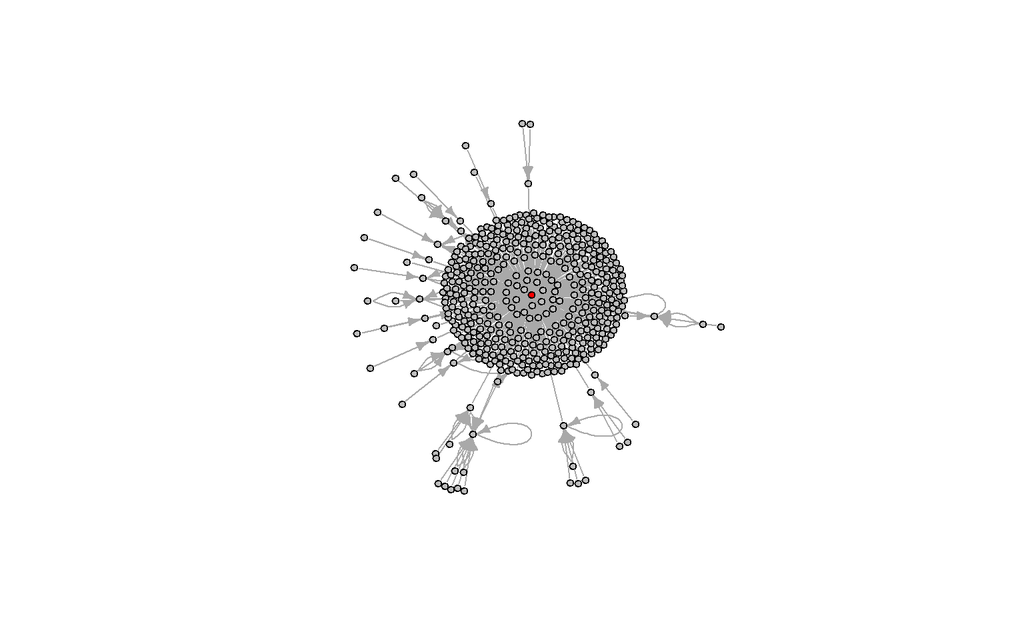

```r
plot(actorGraph, vertex.label = "", vertex.size = 4, edge.arrow.size = 0.5)
```

```r
g2 <- delete.edges(actorGraph, which(E(actorGraph)$edge_type != "reply-comment"))
# By deleting edges other than 'reply-comment', we now have 417 isolates >
# length(which(degree(g2)==0)) [1] 417

g2 <- delete.vertices(g2, which(degree(g2) == 0))  #remove the isolates

V(g2)$color <- "grey"
ind <- tail_of(actorGraph, grep("arson|backburn|climate change", tolower(E(g2)$vosonTxt_comment)))
V(g2)$color[ind] <- "red"

png("youtube_actor_reply.png", width = 600, height = 600)
plot(g2, vertex.label = "", vertex.size = 4, edge.arrow.size = 0.5)
dev.off()
```

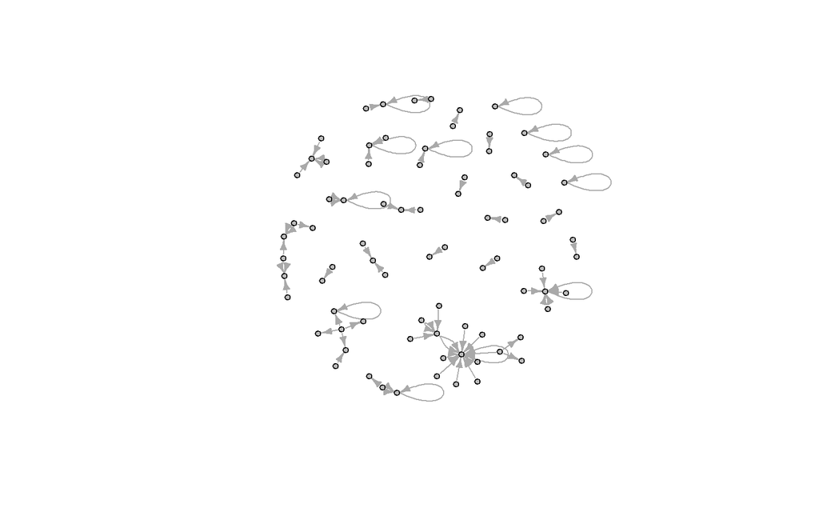

```r
plot(g2, vertex.label = "", vertex.size = 4, edge.arrow.size = 0.5)
```

Son olarak, `AddVideoData()` işlevi, ağ verilerini ek video bilgileriyle tamamlar:

```r
actorNetwork_withVideoInfo <- actorNetwork %>% AddVideoData(youtubeAuth)
```

```
Adding video data to network...Done.
```

`AddVideoData()`, “düğümler” (örnekte `actorNetwork` listesindeki veri çerçevesiyle aynı), “kenarlar” (bu, üç ek sütuna sahiptir: “video_title”, “video_description”, “video_published_at) adlı üç veri çerçevesi içeren adlandırılmış bir liste döndürür”) Ve yeni bir veri çerçevesi" videoları "(anonimliğin korunması için aşağıdakiler değiştirilmiştir):

```r
actorNetwork_withVideoInfo$nodes
```

```
# A tibble: 467 x 3
   id                       screen_name        node_type
   <chr>                    <chr>              <chr>
 1 UC_Qt-9cbzYaRqNjHm-q2O8A Meriç Yavuz        actor
 2 UCvkhiFDz5KTA8fFjMGCaHoA Ahmet Dimli        actor
 3 UCl_ES2BSkhQz8pnOIOI2Bqw Cem Sahin          actor
 4 UCdT3oivOgpUOqcqAUqu7KGQ Demirhan Demir     actor
 5 UCkKFVHUddGnXWupQ6I1DEuw Toylimyrat Mojekov actor
 6 UCIAawnt9_SUXpHWgP6f3uBQ theoriginal639     actor
 7 UCKVNqb1UmZuzR6dJrL89SRA Taqu3              actor
 8 UCD3nvgu64Xa5hvWIkZNrM6A Faruk Kaymak       actor
 9 UChsf2v5-nK3tmZ7hAyK5dUA Adem King          actor
10 UChe6hFlOpwh1n_uD738MTlQ Nihat Böcekci      actor
# ... with 457 more rows
```

```r
actorNetwork_withVideoInfo$edges
```

```
# A tibble: 580 x 9
   from  to    video_id comment_id edge_type vosonTxt_comment video_title
   <chr> <chr> <chr>    <chr>      <chr>     <chr>            <chr>
 1 UC_Q~ UCUA~ xs9XUjH~ UgzzFmpGT~ comment   "Hala izleyen y~ Çöpçüler K~
 2 UCvk~ UCUA~ xs9XUjH~ Ugzahqu0Y~ comment   "Hacerin kardes~ Çöpçüler K~
 3 UCl_~ UCUA~ xs9XUjH~ Ugzng3U05~ comment   "20:39 ahahahah~ Çöpçüler K~
 4 UCdT~ UCUA~ xs9XUjH~ Ugxq2O5Vt~ comment   "1. 10.20"       Çöpçüler K~
 5 UCkK~ UCUA~ xs9XUjH~ UgzSrWbEL~ comment   "Saban dizileri~ Çöpçüler K~
 6 UCIA~ UCUA~ xs9XUjH~ UgzABTmB-~ comment   "uyumayin pezev~ Çöpçüler K~
 7 UCKV~ UCUA~ xs9XUjH~ Ugz5BIVVI~ comment   "Basyapit."      Çöpçüler K~
 8 UCD3~ UCUA~ xs9XUjH~ Ugyv6nLLC~ comment   "çokkkkkkkkkkkk~ Çöpçüler K~
 9 UChs~ UCUA~ xs9XUjH~ UgyCGk9Ai~ comment   "Yandi haa Yand~ Çöpçüler K~
10 UChe~ UCUA~ xs9XUjH~ UgyOrbgm_~ comment   "NB."            Çöpçüler K~
# ... with 570 more rows, and 2 more variables: video_description <chr>,
#   video_published_at <chr>
```

```r
actorNetwork_withVideoInfo$videos
```

```
# A tibble: 1 x 6
  VideoID  VideoTitle  VideoDescription  VideoPublishedAt ChannelID ChannelTitle
  <chr>    <chr>       <chr>             <chr>            <chr>     <chr>
1 xs9XUjH~ Çöpçüler K~ "Çöpçüler Krali,~ 2015-06-12T06:3~ UCUALYmn~ ARZU FILM
```

`AddVideoData()` ’nın isteğe bağlı olarak “düğümler” ve “kenarlar” veri çerçevelerindeki video kimliğine referansları video yayıncısının kanal kimliğiyle değiştirebileceği de belirtilmelidir (bu, `actorSubOnly` parametresini TRUE olarak ayarlayarak yapılır.

## 4.2 Etkinlik Ağı

YouTube etkinlik ağında, düğümler yorumlar veya videolardır (videolar bir başlangıç yorumunu temsil eder).

```r
activityNetwork <- youtubeData %>% Create("activity") %>% AddText(youtubeData)
```

```
Generating youtube activity network...
-------------------------
collected youtube comments | 579
top-level comments         | 500
reply comments             | 79
videos                     | 1
nodes                      | 580
edges                      | 579
-------------------------
Done.
Adding text to network...Done.
```

```r
activityGraph <- activityNetwork %>% Graph(writeToFile = TRUE)
```

```
Creating igraph network graph...
GRAPHML file written: C:/Users/mozturkmen/Desktop/r_ile_veri_analitigi/ders_on_hazirlik/on_hazirlik/2020-11-12_180009-YoutubeActivity.graphml
Done.
```

`Create("activity")`, “düğümler” ve “kenarlar” adlı iki veri çerçevesi içeren adlandırılmış bir liste döndürür (aşağıdakiler anonimliğin korunması için değiştirilmiştir):

```r
activityNetwork$nodes
```

```
# A tibble: 580 x 8
   id    video_id published_at updated_at author_id screen_name node_type
   <chr> <chr>    <chr>        <chr>      <chr>     <chr>       <chr>
 1 Ugzz~ xs9XUjH~ 2020-11-12T~ 2020-11-1~ UC_Qt-9c~ Meriç Yavuz comment
 2 Ugza~ xs9XUjH~ 2020-11-11T~ 2020-11-1~ UCvkhiFD~ Ahmet Dimli comment
 3 Ugzn~ xs9XUjH~ 2020-11-11T~ 2020-11-1~ UCl_ES2B~ Cem Sahin   comment
 4 Ugxq~ xs9XUjH~ 2020-11-11T~ 2020-11-1~ UCdT3oiv~ Demirhan D~ comment
 5 UgzS~ xs9XUjH~ 2020-11-11T~ 2020-11-1~ UCkKFVHU~ Toylimyrat~ comment
 6 UgzA~ xs9XUjH~ 2020-11-11T~ 2020-11-1~ UCIAawnt~ theorigina~ comment
 7 Ugz5~ xs9XUjH~ 2020-11-10T~ 2020-11-1~ UCKVNqb1~ Taqu3       comment
 8 Ugyv~ xs9XUjH~ 2020-11-10T~ 2020-11-1~ UCD3nvgu~ Faruk Kaym~ comment
 9 UgyC~ xs9XUjH~ 2020-11-10T~ 2020-11-1~ UChsf2v5~ Adem King   comment
10 UgyO~ xs9XUjH~ 2020-11-10T~ 2020-11-1~ UChe6hFl~ Nihat Böce~ comment
# ... with 570 more rows, and 1 more variable: vosonTxt_comment <chr>
```

```r
activityNetwork$edges
```

```
# A tibble: 579 x 3
   from                       to                  edge_type
   <chr>                      <chr>               <chr>
 1 UgzzFmpGTcBkLRnfM394AaABAg VIDEOID:xs9XUjHvZsM comment
 2 Ugzahqu0YIetzvDAqad4AaABAg VIDEOID:xs9XUjHvZsM comment
 3 Ugzng3U05l66i5tsG9p4AaABAg VIDEOID:xs9XUjHvZsM comment
 4 Ugxq2O5VtjZ-pcLRYPx4AaABAg VIDEOID:xs9XUjHvZsM comment
 5 UgzSrWbELU4q_3ymnJB4AaABAg VIDEOID:xs9XUjHvZsM comment
 6 UgzABTmB-efl2ZBNIz54AaABAg VIDEOID:xs9XUjHvZsM comment
 7 Ugz5BIVVIxvSYMnJLNt4AaABAg VIDEOID:xs9XUjHvZsM comment
 8 Ugyv6nLLCVhQKpTbixd4AaABAg VIDEOID:xs9XUjHvZsM comment
 9 UgyCGk9AincV-iY7sMJ4AaABAg VIDEOID:xs9XUjHvZsM comment
10 UgyOrbgm_XahtcE7mYJ4AaABAg VIDEOID:xs9XUjHvZsM comment
# ... with 569 more rows
```

Yukarıda, yorum metin verilerini ağ veri çerçevesine eklemek için `AddText()` kullanıldığını ve bir düğüm özelliği olarak saklandığını unutmayın. Bu liste daha sonra bir igraph grafik nesnesi döndüren Graph () ’e iletilir (bu anonimleştirilmiştir):

Örnek YouTube etkinlik ağı, 580 düğüm ve 579 kenar içerir. Aşağıda, videonun kırmızı bir düğümle gösterildiği ağın bir igrahp görselleştirmesi ve mavi şu terimlerden birini içeren yorumları belirtir: “sokak”, “Kemal”, “dram”.

```r
V(activityGraph)$color <- "grey"
V(activityGraph)$color[which(V(activityGraph)$node_type == "video")] <- "red"
ind <- grep("sokak|kemal|dram", tolower(V(activityGraph)$vosonTxt_comment))
V(activityGraph)$color[ind] <- "blue"

png("youtube_activity.png", width = 600, height = 600)
plot(activityGraph, vertex.label = "", vertex.size = 4, edge.arrow.size = 0.5)
dev.off()
```

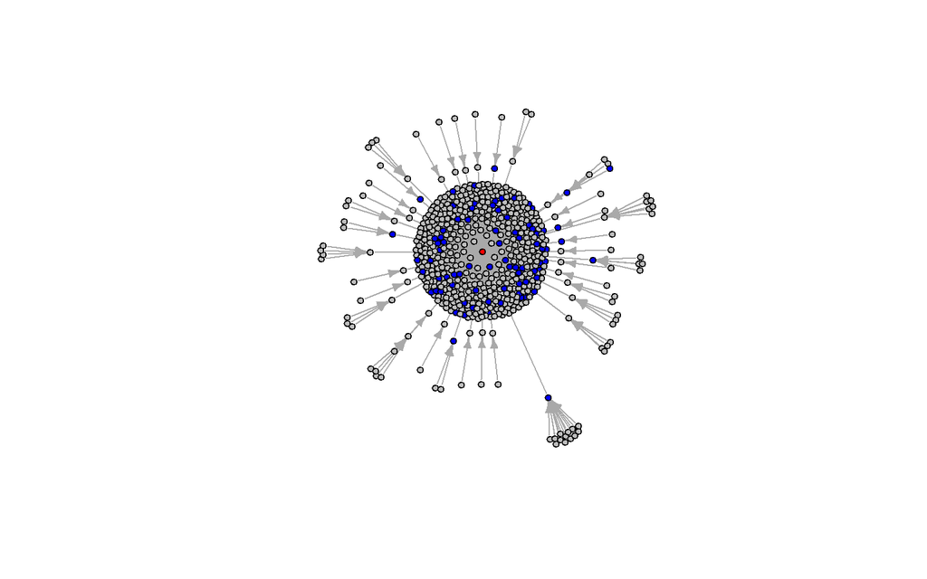

```r
plot(activityGraph, vertex.label = "", vertex.size = 4, edge.arrow.size = 0.5)
```

YouTube etkinlik ağı (kırmızı düğüm videodur, mavi düğümler belirli terimlerden bahseden yorumlardır).